# Homework 10

Solutions for Questions 1 and 2 will be available after Monday, November 2, 2026. No solution will be provided for Question 3.

Use the RLT package for Questions 1 and 2: `RLT` in R or `rlt` in Python. The node-size parameter is `nmin` in R and `min_samples_leaf` in Python; both stop splitting a node when it contains at most that many observations. The candidate-predictor parameter is `mtry` in both languages. Use ordinary random forests, with reinforcement turned off.

```r
library(RLT)
library(MASS)
library(tidyverse)
```

## Question 1: Bias-variance trade-off simulation

Two important tuning parameters of random forests are node size and `mtry`. We have performed some preliminary analysis in class. The goal of this question is to perform a larger simulation study for these two tuning parameters.

Consider a regression model with five jointly normally distributed predictors. Each predictor has mean 0 and variance 1, and the correlation between any two different predictors is 0.3. The response is

$$Y=X_1+X_3+X_5+\varepsilon,
\qquad \varepsilon\sim N(0,1),$$

where the noise is independent of the predictors. Thus the true regression function is $f(\mathbf{x})=x_1+x_3+x_5$.

1. Set up a simulation study with 100 repetitions. Generate 200 test predictor vectors once and keep them fixed. In each repetition, generate 200 new training observations and use the same training data for all tuning settings. Fit 500-tree forests, drawing 200 observations with replacement for each tree. Make the following two comparisons:
   - Fix `mtry` at 3 and vary node size over $1,5,10,20,30$.
   - Fix node size at 10 and vary `mtry` over $1,2,3,4,5$.

   Leave all other fitting parameters at their defaults. Record the predictions at each test point across repetitions. For each setting, estimate the squared bias and variance at each test point, then average them over the 200 test points. Compare predictions with $f(\mathbf{x})$ when estimating bias. Produce two figures, one for each tuning parameter, showing the averaged squared bias and variance. Set a random seed and report it.

   My random seed was 9.

   ```r
   set.seed(9)
   n = 200
   mu = c(0, 0, 0, 0, 0)
   Sigma = matrix(0.3, nrow = 5, ncol = 5)
   diag(Sigma) = 1
   X = mvrnorm(n = n, mu = mu, Sigma = Sigma)
   X = as.data.frame(X)
   names(X) = c("X1", "X2", "X3", "X4", "X5")
   y = X$X1 + X$X3 + X$X5

   n = 200
   mu = c(0, 0, 0, 0, 0)
   Sigma = matrix(0.3, nrow = 5, ncol = 5)
   diag(Sigma) = 1
   Xtest = mvrnorm(n = n, mu = mu, Sigma = Sigma)
   Xtest = as.data.frame(Xtest)
   names(Xtest) = c("X1", "X2", "X3", "X4", "X5")
   ytest = Xtest$X1 + Xtest$X3 + Xtest$X5

   settings1 = data.frame(experiment = "nmin", nmin = c(1, 5,10,20,30), mtry = 3)
   settings2 = data.frame(experiment = "mtry", nmin = 10, mtry = c(1,2,3,4,5))
   settings = rbind(settings1, settings2)
   predictions = array(NA_real_, dim = c(200, 100, 10))

   for (r in 1:100) {
     X = mvrnorm(n = 200, mu = mu, Sigma = Sigma)
     Xtrain = as.data.frame(X)
     names(Xtrain) = c("X1", "X2", "X3", "X4", "X5")
     ytrain = Xtrain$X1 + Xtrain$X3 + Xtrain$X5 + rnorm(200,0,1)

     for (k in 1:10){
       fit = RLT::RLT(
         Xtrain, ytrain, model = "regression", ntrees = 500,
         mtry = settings$mtry[k], nmin = settings$nmin[k],
         resample.prob = 1)

     pred = predict(fit, Xtest, keep.all = TRUE)
     predictions[,r,k] = as.numeric(pred$Prediction)
     }
   }
   bias2 = numeric(nrow(settings))
   variance = numeric(nrow(settings))
   for (k in 1:nrow(settings)) {
       pred_k = predictions[, , k]
       mean_pred = rowMeans(pred_k)
       bias_at_x = (mean_pred - ytest)^2
       variance_at_x = apply(pred_k, 1, var)
     bias2[k] = mean(bias_at_x)
     variance[k] = mean(variance_at_x)
   }
   results = cbind(
     settings,
     Squared_Bias = bias2,
     Variance = variance
   )

   knitr::kable(results, digits = 4)
   ```

   | experiment | nmin | mtry | Squared_Bias | Variance |
   | --- | --- | --- | --- | --- |
   | nmin | 1 | 3 | 0.2297 | 0.1100 |
   | nmin | 5 | 3 | 0.2270 | 0.0990 |
   | nmin | 10 | 3 | 0.2460 | 0.0813 |
   | nmin | 20 | 3 | 0.3177 | 0.0659 |
   | nmin | 30 | 3 | 0.4074 | 0.0603 |
   | mtry | 10 | 1 | 0.6773 | 0.0406 |
   | mtry | 10 | 2 | 0.3253 | 0.0618 |
   | mtry | 10 | 3 | 0.2462 | 0.0816 |
   | mtry | 10 | 4 | 0.2140 | 0.0994 |
   | mtry | 10 | 5 | 0.2019 | 0.1136 |

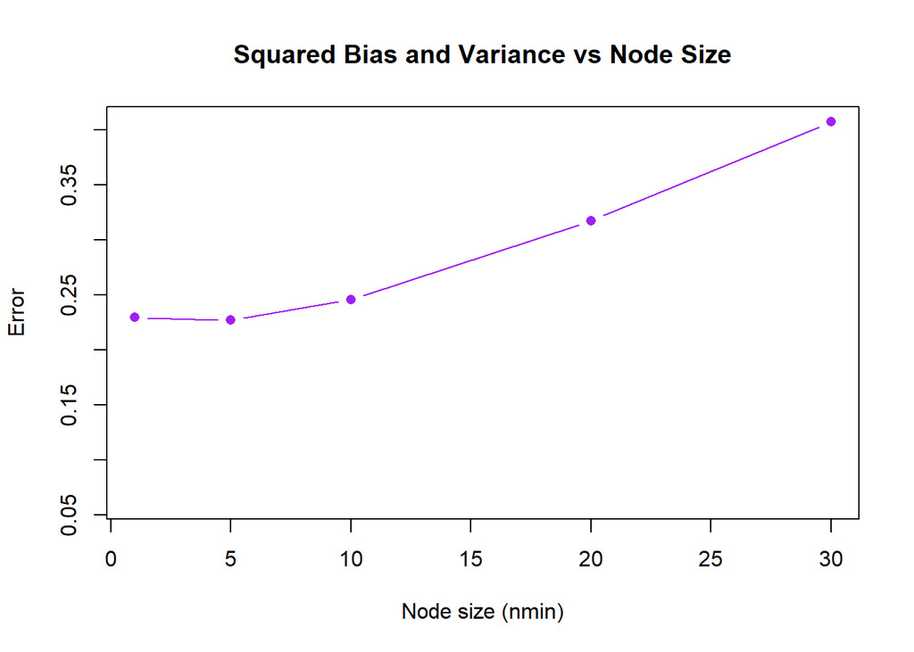

   ```r
   idx1 = settings$experiment == "nmin"

   plot(
     settings$nmin[idx1],
     bias2[idx1],
     type = "b",
     pch = 16,
     col = "purple",
     ylim = range(c(bias2[idx1], variance[idx1])),
     xlab = "Node size (nmin)",
     ylab = "Error",
     main = "Squared Bias and Variance vs Node Size"
   )
   ```

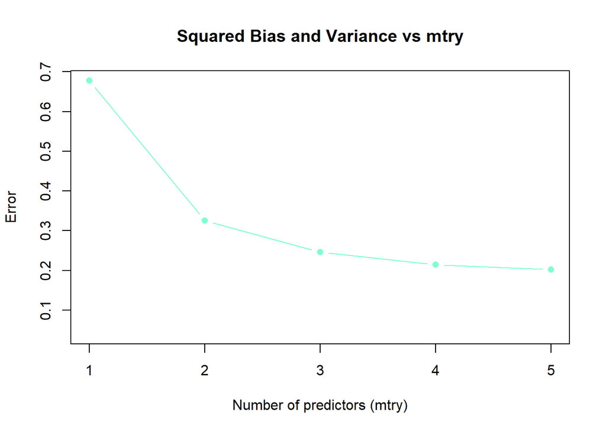

   ```r
   idx2 = settings$experiment == "mtry"

   plot(
     settings$mtry[idx2],
     bias2[idx2],
     type = "b",
     pch = 16,
     col = "aquamarine",
     ylim = range(c(bias2[idx2], variance[idx2])),
     xlab = "Number of predictors (mtry)",
     ylab = "Error",
     main = "Squared Bias and Variance vs mtry"
   )
   ```

```r
n = 100
mu = c(0, 0, 0, 0, 0)
Sigma = matrix(0.3, nrow = 5, ncol = 5)
diag(Sigma) = 1
Xtest = mvrnorm(n = n, mu = mu, Sigma = Sigma)
Xtest = as.data.frame(Xtest)
names(Xtest) = c("X1", "X2", "X3", "X4", "X5")
ytest = Xtest$X1 + Xtest$X3 + Xtest$X5

settings1 = data.frame(experiment = "nmin", nmin = c(1, 5,10,20,30), mtry = 3)
settings2 = data.frame(experiment = "mtry", nmin = 10, mtry = c(1,2,3,4,5))
settings = rbind(settings1, settings2)
predictions = array(NA_real_, dim = c(100, 100, 10))

for (r in 1:100) {
  X = mvrnorm(n = 200, mu = mu, Sigma = Sigma)
  Xtrain = as.data.frame(X)
  names(Xtrain) = c("X1", "X2", "X3", "X4", "X5")
  ytrain = Xtrain$X1 + Xtrain$X3 + Xtrain$X5 + rnorm(100,0,1)

  for (k in 1:10){
    fit = RLT::RLT(
      Xtrain, ytrain, model = "regression", ntrees = 500,
      mtry = settings$mtry[k], nmin = settings$nmin[k],
      resample.prob = 1)

    pred = predict(fit, Xtest, keep.all = TRUE)
    predictions[,r,k] = as.numeric(pred$Prediction)
  }
}
bias2 = numeric(nrow(settings))
variance = numeric(nrow(settings))
for (k in 1:nrow(settings)) {
  pred_k = predictions[, , k]
  mean_pred = rowMeans(pred_k)
  bias_at_x = (mean_pred - ytest)^2
  variance_at_x = apply(pred_k, 1, var)
  bias2[k] = mean(bias_at_x)
  variance[k] = mean(variance_at_x)
}
results = cbind(
  settings,
  Squared_Bias = bias2,
  Variance = variance
)

knitr::kable(results, digits = 4)
```

| experiment | nmin | mtry | Squared_Bias | Variance |
| --- | --- | --- | --- | --- |
| nmin | 1 | 3 | 0.2096 | 0.1071 |
| nmin | 5 | 3 | 0.2086 | 0.0982 |
| nmin | 10 | 3 | 0.2290 | 0.0805 |
| nmin | 20 | 3 | 0.2974 | 0.0657 |
| nmin | 30 | 3 | 0.3830 | 0.0583 |
| mtry | 10 | 1 | 0.6915 | 0.0451 |
| mtry | 10 | 2 | 0.3166 | 0.0638 |
| mtry | 10 | 3 | 0.2275 | 0.0806 |
| mtry | 10 | 4 | 0.1945 | 0.0959 |
| mtry | 10 | 5 | 0.1762 | 0.1079 |

## Question 2: Tuning random forests for MNIST

Use `mnist-first2000.csv.gz` from the combined ZIP. It contains 2,000 MNIST observations, with the digit label `Digit` and 784 pixel values.

- From the first 1,000 observations, keep digits 1, 6, and 7 as the training data. From the remaining 1,000 observations, keep the same digits as the test data.
- Fit PCA to the training pixels, centering but not scaling them. Use the first 20 principal components as predictors, and project the test observations using the same training means and loadings.

Complete the following tasks using RLT classification forests with 1,000 trees. For each tree, draw a bootstrap sample of the same size as the training set.

1. Fit a random forest with the default `mtry` and node-size settings. Report the out-of-bag (OOB) misclassification rate.

   ```r
   df = read_csv("C:/Users/sophi/OneDrive/stat432-fall2026/homework/week-10/data/mnist-first2000.csv.gz")
   df_train = df[1:1000,]
   df_train = df_train %>%
     filter(Digit == 1 | Digit == 6 | Digit == 7)
   df_train_y = df_train %>%
     dplyr::select(Digit)
   df_train_y = factor(df_train_y$Digit)
   df_train = df_train %>%
     dplyr::select(-Digit)
   df_test = df[1001:2000, ]
   df_test = df_test %>%
     filter(Digit == 1 | Digit == 6 | Digit == 7)
   df_test_y = df_test %>%
     dplyr::select(Digit)
   df_test_y = factor(df_test_y$Digit)

   nsample = dim(df_train)[1]
   pca = prcomp(df_train, center = TRUE, scale. = FALSE)
   traincomp = pca$x[,1:20]
   pca_test = predict(pca, newdata = df_test)[, 1:20]
   ```

   ```r
   fit = RLT::RLT(
     traincomp, df_train_y, model = "classification", ntrees = 1000, resample.prob = 1)
   ooderror = fit$AllError[1000, "nonPermute"]
   ```

2. Construct a grid of `mtry` and node-size values to tune the model. Select the setting using OOB misclassification rate. Report the OOB error for each setting and the selected values. Calculate and present the selected forest’s OOB permutation variable importance for the 20 principal components. Comment on your results.

   ```r
   alltune <- expand.grid(nmin = c(3, 5,7,9,10), mtry = c(1,3,5, 12,20))
   allerror <- numeric(nrow(alltune))

   for (k in 1:nrow(alltune)) {
     fit = RLT::RLT(
       traincomp, df_train_y, model = "classification", ntrees = 1000, resample.prob = 1)
     allerror[k] = fit$AllError[1000, "nonPermute"]
   }
   knitr::kable(cbind(alltune, OOB_MSE = allerror), digits = 3)
   ```

   | nmin | mtry | OOB_MSE |
   | --- | --- | --- |
   | 3 | 1 | 0.246 |
   | 5 | 1 | 0.290 |
   | 7 | 1 | 0.107 |
   | 9 | 1 | 0.142 |
   | 10 | 1 | 0.246 |
   | 3 | 3 | 0.158 |
   | 5 | 3 | 0.152 |
   | 7 | 3 | 0.240 |
   | 9 | 3 | 0.098 |
   | 10 | 3 | 0.107 |
   | 3 | 5 | 0.223 |
   | 5 | 5 | 0.248 |
   | 7 | 5 | 0.221 |
   | 9 | 5 | 0.123 |
   | 10 | 5 | 0.205 |
   | 3 | 12 | 0.112 |
   | 5 | 12 | 0.186 |
   | 7 | 12 | 0.150 |
   | 9 | 12 | 0.303 |
   | 10 | 12 | 0.308 |
   | 3 | 20 | 0.189 |
   | 5 | 20 | 0.181 |
   | 7 | 20 | 0.316 |
   | 9 | 20 | 0.243 |
   | 10 | 20 | 0.208 |

   | PC1 | PC2 | PC3 | PC4 | PC5 | PC6 | PC7 | PC8 | PC9 | PC10 | PC11 | PC12 | PC13 | PC14 | PC15 | PC16 | PC17 | PC18 | PC19 | PC20 |
   | --- | --- | --- | --- | --- | --- | --- | --- | --- | --- | --- | --- | --- | --- | --- | --- | --- | --- | --- | --- |
   | 0.1469 | 0.1978 | 0.0516 | 0.0443 | 0.0506 | 0.0496 | 0.0432 | 0.0264 | 0.0253 | 0.0322 | 0.037 | 0.0286 | 0.0258 | 0.0262 | 0.0246 | 0.0313 | 0.0224 | 0.025 | 0.0156 | 0.0226 |

   The first two predictors have the largest importance value, and then all of the other 18 are fairly similar.
3. Apply the selected model to the test data and report the misclassification rate and confusion matrix. Use the test labels only for this final assessment.

   ```r
   fitc = RLT::RLT(
     pca_test, df_test_y, model = "classification", ntrees = 1000, mtry = 1, nmin = 7,
     resample.prob = 1,
     importance = TRUE
   )
   allerrorc = fitc$AllError[1000, "nonPermute"]
   allerrorc
   ```

   ```
   [1] 0.4642857
   ```

   ```r
   predc = predict(fitc, pca_test)
   ```

   ```r
   table(
     Prediction = predc$Prediction,
     Actual = df_test_y
   )
   ```

   ```
             Actual
   Prediction   1   6   7
            0 104   0   0
            1   0 106   0
            2   0   0 107
   ```

## Question 3: Planning a random-forest analysis skill

In earlier homework, some students wrote long skill files with detailed instructions, while others wrote short skills emphasizing their specific requirements or references. These approaches may perform differently depending on the AI and the task. A capable AI may already know standard ways to perform an analysis, so some instructions may be redundant, add little value, or sometimes make the analysis worse. It may be more useful to specify your personal choices for the analysis. An AI with more limited knowledge may benefit from detailed instructions that remind it of the steps to perform.

1. Write one paragraph describing how you would write a skill that directs an AI to perform a random-forest analysis and produce a report for a future dataset. Discuss how you would balance standard analysis instructions with your personal preferences, considering the AI’s capabilities.

   I typically look at the notes and homework to see what steps were used to select the final model and then provide a basic outline of the process it should follow. For example, for random forest, I would instruct it to tune specific parameters like mtry and nmin. I would also include any specific guidelines we followed for class, such as instructions on scaling or other parameters to keep at their default setting. I would also outline some of the preferred graphs or tables, such as a confusion matrix. I would try to keep most of the specific details fairly vague, but for something like the graph I would provide more guidelines based on our previous skills. I also would ask AI for its feedback on how the skill is set up. To integrate its feedback, I normally try to take the ideas and reword or change them so they fit with the rest of the skill and are understandable. I would also insert my personal preferences on the display of the paper because it sometimes doesn’t knit correctly at first when I’ve done other skills. The AI I use is not the most powerful though, so I try to be mostly vague to not overwhelm it.
2. Provide **10 instructions** you would consider including in the skill, **ordered from the most basic instructions to the more personal preferences**. Your list may cover computation, tuning, tables, figures, interpretation, presentation, or other aspects of a random-forest report.
   - Keep the length of the report to one printed page while making sure graphs are still easy to see.
   - One of the figures should show the bias-variance tradeoff of different tuning parameters considered.
   - Clearly explain what the final selected tuning parameters were and what statistical measure was used to select them.
   - Utilize the RLT package specifically to fit the random forest package.
   - Check structure of data to monitor missing data, unusual observations, or other limitations that could obstruct the use of random forests.
   - In the introduction, briefly explain what the data is and give an overview of the key predictors/response variable.
   - For ease of interpretation, display a confusion matrix in addition to the OOB error.
   - Ensure the figures are readable by including a concise label for x and y axes, bright colors, and a legend.
   - In the conclusion/interpretation, include overview of why random forest was chosen in addition to the tuning parameters and situate in broader context of the data to provide an applicable takeaway.
   - Keep code simple and easy to understand while still computing all necessary components.

You only need to discuss how the skill should be written. You are not required to write a complete skill file or test it.